# Modelagem e criação de modelos de classificação com machine learning para algoritmos de tradding

Gabriel Ghellere 2019

## Workflow

Baseado do livro Machine Learning Hands On

[figure not shown]

### 1 Frame the problem and look at the big picture

Já sabemos que algoritmos de Machine Learning são válidos para a criação de estratégias para trader bots então agora nossa decisão é qual abortagem que iremos utilizar para a resolver o problema.

Existem inúmeras opções de algoritmos e técnicas para aplicar algoritmos de Machine Learning para trade. Pode-se usar técnicas de predição com redes neurais (LSTM OU CNN) ou usar aprendizado por reforço, mas nesse caso vamos modelar para utilizar um algoritmo de classificação.

```python
import requests, json
from binance.client import Client
from binance.enums import *

import pandas as pd
import numpy as np
import time
from datetime import datetime

from math import pi
import bokeh
#bokeh.sampledata.download()
from bokeh.plotting import figure, show, output_file, output_notebook
from bokeh.sampledata.stocks import MSFT

%matplotlib inline

import warnings
warnings.filterwarnings('ignore')


class Aquisition(object):


    def __init__(self):
        self.client = Client('', '')
        self.df = pd.DataFrame(columns= ['Open_time', 'Open', 'High', 'Low', 'Close', 'Volume', 'Close_time'])

    def cast_to_dataframe(self, opentime, lopen, lhigh, llow, lclose, lvol, closetime):
        self.df['Open_time'] = opentime
        self.df["date"] = opentime
        self.df['Open'] = np.array(lopen).astype(np.float)
        self.df['High'] = np.array(lhigh).astype(np.float)
        self.df['Low'] = np.array(llow).astype(np.float)
        self.df['Close'] = np.array(lclose).astype(np.float)
        self.df['Volume'] = np.array(lvol).astype(np.float)
        self.df['Close_time'] = closetime
        self.df["date"] = pd.to_datetime(self.df['date'],unit='ms')

    def parse(self, candles):
        opentime, lopen, lhigh, llow, lclose, lvol, closetime = [], [], [], [], [], [], []
        for candle in candles:
            opentime.append(candle[0])
            lopen.append(candle[1])
            lhigh.append(candle[2])
            llow.append(candle[3])
            lclose.append(candle[4])
            lvol.append(candle[5])
            closetime.append(candle[6])
        self.cast_to_dataframe(opentime, lopen, lhigh, llow, lclose, lvol, closetime)

    def get_candles(self):
        candles = self.client.get_historical_klines("BTCUSDT", Client.KLINE_INTERVAL_1HOUR, "1 Ago, 2018")
        #candles = self.client.get_klines(symbol='BTCUSDT', interval=Client.KLINE_INTERVAL_1DAY)
        self.parse(candles)
        return self.df

    def get_price_now(self):
        r = requests.get("https://www.binance.com/api/v3/ticker/price?symbol=BTCUSDT")
        r = r.content
        jsonResponse = json.loads(r.decode('utf-8'))
        return float(jsonResponse['price'])


    def plot_candles(self):
        df = self.df[450:]
        df["date"] = df["Open_time"]
        df["date"] = pd.to_datetime(self.df['date'],unit='ms')
        inc = df.Close > df.Open
        dec = df.Open > df.Close
        w = 12*60*60*1000 # half day in ms
        TOOLS = "pan,wheel_zoom,box_zoom,reset,save"
        p = figure(x_axis_type="datetime", tools=TOOLS, plot_width=1000, title = "BITCOIN Candlestick")
        p.xaxis.major_label_orientation = pi/4
        p.grid.grid_line_alpha=0.3
        p.segment(df.date, df.High, df.date, df.Low, color="black")
        p.vbar(df.date[inc], w, df.Open[inc], df.Close[inc], fill_color="#006400", line_color="black")
        p.vbar(df.date[dec], w, df.Open[dec], df.Close[dec], fill_color="#F2583E", line_color="black")
        output_notebook()
        return p
```

O dataframe resultante pode ser visto abaixo:

```python
candles = Aquisition()
dataframe = candles.get_candles()
dataframe.head()
```

|  | Open_time | Open | High | Low | Close | Volume | Close_time | date |
| --- | --- | --- | --- | --- | --- | --- | --- | --- |
| 0 | 1533081600000 | 7735.67 | 7750.00 | 7654.51 | 7672.98 | 1634.481821 | 1533085199999 | 2018-08-01 00:00:00 |
| 1 | 1533085200000 | 7673.23 | 7689.99 | 7551.00 | 7553.16 | 3094.454503 | 1533088799999 | 2018-08-01 01:00:00 |
| 2 | 1533088800000 | 7551.51 | 7577.00 | 7501.00 | 7550.01 | 2921.913184 | 1533092399999 | 2018-08-01 02:00:00 |
| 3 | 1533092400000 | 7550.04 | 7558.32 | 7500.00 | 7539.99 | 1710.712768 | 1533095999999 | 2018-08-01 03:00:00 |
| 4 | 1533096000000 | 7540.00 | 7580.00 | 7525.00 | 7534.66 | 1669.251784 | 1533099599999 | 2018-08-01 04:00:00 |

### 3 Explore the data to gain insigts

Agora é necessário ter um entendimento melhor do problema, então em seguida faremos algumas análises em nossos dados para tentar obter algum insight interessante.

```python
dataframe.shape
```

```
(5192, 8)
```

Então plota-se com o bokeh os candles com um stock chart no formato OHLCV

```python
plot = candles.plot_candles()
show(plot)
```

[interactive chart not shown]

```python
class Bbands(Aquisition):


    def __init__(self, nDer = 2, period = 20):
        super(Bbands, self).__init__()
        self.candles = super().get_candles()
        self.nDer = nDer
        self.period = period

    def eval_boillinger_bands(self):
        self.candles['30 Day MA'] = self.candles['Close'].rolling(window=self.period).mean()
        self.candles['30 Day STD'] = self.candles['Close'].rolling(window=self.period).std()
        self.candles['Upper Band'] = self.candles['30 Day MA'] + (self.candles['30 Day STD'] * self.nDer)
        self.candles['Lower Band'] = self.candles['30 Day MA'] - (self.candles['30 Day STD'] * self.nDer)

    def configure_plot(self, df):
        TOOLS = "pan,wheel_zoom,box_zoom,reset,save"
        p = figure(x_axis_type="datetime", tools=TOOLS, plot_width=1000, title = "Bbands Chart")
        p.xaxis.major_label_orientation = pi/4
        p.grid.grid_line_alpha=0.3
        p.line(df.date, df.Close, line_color="black")
        p.line(df.date, df['30 Day MA'], line_color="red", legend="30 Day MA", muted_alpha=0.2)
        p.line(df.date, df['Upper Band'], line_color="blue", legend="Upper Band", muted_alpha=0.2)
        p.line(df.date, df['Lower Band'], line_color="green", legend="Lower Band", muted_alpha=0.2)

        p.legend.location = "top_left"
        p.legend.click_policy="mute"
        return p

    def plot_bands(self):
        df = self.candles
        p = self.configure_plot(df)
        output_notebook()
        return p

    def plot_cross_points(self):
        self.eval_boillinger_bands()

        self.candles['up_cross'] = np.where((self.candles['Close'] >= self.candles['Upper Band'])
                                            , self.candles['Close'], None)
        self.candles['down_cross'] = np.where((self.candles['Close'] <= self.candles['Lower Band'])
                                              , self.candles['Close'], None)

        p = self.configure_plot(self.candles)
        p.circle(self.candles.date, self.candles['up_cross'], size=5, color="red", alpha=1, legend="Up cross")
        p.circle(self.candles.date, self.candles['down_cross'], size=5, color="green", alpha=1,legend="Down cross")
        output_notebook()
        return p

    def detect_cross(self):
        self.eval_boillinger_bands()
        self.candles['up_cross'] = np.where((self.candles['Close'] >= self.candles['Upper Band']) , 1, 0)
        self.candles['down_cross'] = np.where((self.candles['Close'] <= self.candles['Lower Band']) , 1,  0)
```

### Visualização das bandas:

Pode-se visualizar as bandas calculadas para uma melhor interpretação

```python
bands = Bbands()
bands.eval_boillinger_bands()
plot = bands.plot_bands()
show(plot)
```

[interactive chart not shown]

# Cross

Outro ponto importante é a possibilidade de adicionar uma interpretação das bandas extraindo mais um sinal delas. São os pontos de cruzamento da linha do fechamento (close) com as bandas superiores e inferiores.

```python
bands.plot_cross_points()
```

**Figure**(

id = '57b93090-3eea-49d5-bf82-db5e655dfe5a', …)

Adicionando todos esse indicadores nosso dataframe fica o seguinte:

```python
bands.detect_cross()
bands.df.head()
```

|  | Open_time | Open | High | Low | Close | Volume | Close_time | date | 30 Day MA | 30 Day STD | Upper Band | Lower Band | up_cross | down_cross |
| --- | --- | --- | --- | --- | --- | --- | --- | --- | --- | --- | --- | --- | --- | --- |
| 0 | 1533081600000 | 7735.67 | 7750.00 | 7654.51 | 7672.98 | 1634.481821 | 1533085199999 | 2018-08-01 00:00:00 | NaN | NaN | NaN | NaN | 0 | 0 |
| 1 | 1533085200000 | 7673.23 | 7689.99 | 7551.00 | 7553.16 | 3094.454503 | 1533088799999 | 2018-08-01 01:00:00 | NaN | NaN | NaN | NaN | 0 | 0 |
| 2 | 1533088800000 | 7551.51 | 7577.00 | 7501.00 | 7550.01 | 2921.913184 | 1533092399999 | 2018-08-01 02:00:00 | NaN | NaN | NaN | NaN | 0 | 0 |
| 3 | 1533092400000 | 7550.04 | 7558.32 | 7500.00 | 7539.99 | 1710.712768 | 1533095999999 | 2018-08-01 03:00:00 | NaN | NaN | NaN | NaN | 0 | 0 |
| 4 | 1533096000000 | 7540.00 | 7580.00 | 7525.00 | 7534.66 | 1669.251784 | 1533099599999 | 2018-08-01 04:00:00 | NaN | NaN | NaN | NaN | 0 | 0 |

Agora além dos indicadores do gráfico OHLCV ainda temos uma média móvel, o desfio padrão o valor das Bandas de Boillinger e o cruzamento das mesmas. Observe que poluimos o dataframe com campos de data missing (NaN) e esses pontos se encontram nos candles iniciais antes de existirem pontos suficientes para calcular as médias móveis.

## Adicionando mais indicadores

Agora que sabemos o que são indicadores e como implementa-los vamos ao modo mais fácil adicionando mais alguns usando a biblioteca pyti

```python
from pyti.exponential_moving_average import exponential_moving_average as ema
from pyti.aroon import aroon_down, aroon_up
from pyti.ichimoku_cloud import tenkansen, kijunsen, chiku_span, senkou_a, senkou_b
from pyti.momentum import momentum

class Indicators():
    def __init__(self, candles):
        self.candles = candles

    def add_indicators(self):
        self.candles = self.candles.drop(['Open_time', 'Close_time'], axis=1)
        self.candles['EMA - 15'] = ema(self.candles['Close'].tolist(), 15)
        self.candles['aaron down'] = aroon_down(self.candles['Close'].tolist(), 25)
        self.candles['aaron up'] = aroon_up(self.candles['Close'].tolist(), 25)
        self.candles['tenkansen'] = tenkansen(self.candles['Close'].tolist())
        self.candles['kijunsen'] = kijunsen(self.candles['Close'].tolist())
        self.candles['momentun'] = momentum(self.candles['Close'], 15)
        return self.candles
```

Os indicadores escolhidos (arbitrariamente) foram:

- Media móvel esponencial de 15 valores
- arron up e down
- Nuvens de ichimoku (tenkasen, kijusen)
- momentun

## DESAFIOS

- #### Quantos indicadores são o suficiente?
- #### Quais os melhores indicadores?
- #### Indicadores realmente conseguem expressar bem a reação do mercado?
- #### Indicadores com base em análise natural são válidos?
- #### Pode-se usar a saída de um algoritmo de machine learning como um indicador para outro algoritmo?

#### O dataframe resultante é o seguinte:

```python
idc = Indicators(bands.df)
df = idc.add_indicators()
df.head()
```

|  | Open | High | Low | Close | Volume | date | 30 Day MA | 30 Day STD | Upper Band | Lower Band | up_cross | down_cross | EMA - 15 | aaron down | aaron up | tenkansen | kijunsen | momentun |
| --- | --- | --- | --- | --- | --- | --- | --- | --- | --- | --- | --- | --- | --- | --- | --- | --- | --- | --- |
| 0 | 7735.67 | 7750.00 | 7654.51 | 7672.98 | 1634.481821 | 2018-08-01 00:00:00 | NaN | NaN | NaN | NaN | 0 | 0 | NaN | NaN | NaN | NaN | NaN | NaN |
| 1 | 7673.23 | 7689.99 | 7551.00 | 7553.16 | 3094.454503 | 2018-08-01 01:00:00 | NaN | NaN | NaN | NaN | 0 | 0 | NaN | NaN | NaN | NaN | NaN | NaN |
| 2 | 7551.51 | 7577.00 | 7501.00 | 7550.01 | 2921.913184 | 2018-08-01 02:00:00 | NaN | NaN | NaN | NaN | 0 | 0 | NaN | NaN | NaN | NaN | NaN | NaN |
| 3 | 7550.04 | 7558.32 | 7500.00 | 7539.99 | 1710.712768 | 2018-08-01 03:00:00 | NaN | NaN | NaN | NaN | 0 | 0 | NaN | NaN | NaN | NaN | NaN | NaN |
| 4 | 7540.00 | 7580.00 | 7525.00 | 7534.66 | 1669.251784 | 2018-08-01 04:00:00 | NaN | NaN | NaN | NaN | 0 | 0 | NaN | NaN | NaN | NaN | NaN | NaN |

### A análise de correlação

Para verificar a correlação entre os indicadores pode-se criar uma matriz com os coeficientes de pearson utilizando o seaborn.

Os coefieientes de pearson são úteis pois mostram a correlação entre duas séries temporais.

Remove-se as colunas High, Low e Open para se observar mais facilmente a correlação entre as variáveis Close e os demais indicadores.

```python
import matplotlib.pyplot as plt
import seaborn as sns
class Corr(object):
    def __init__(self, df):
        self.df = df
        try:
            self.df = self.df.drop(['High', 'Low', 'Open'], axis=1)
        except:
            pass

    def pearson(self):
        plt.figure(figsize=(12,8))
        kwargs = {'fontsize':12,'color':'black'}
        sns.heatmap(self.df.corr(),annot=True,robust=True)
        plt.title('Correlation Analysis',**kwargs)
        plt.tick_params(length=3,labelsize=12,color='black')
        plt.yticks(rotation=0)
        plt.show()
```

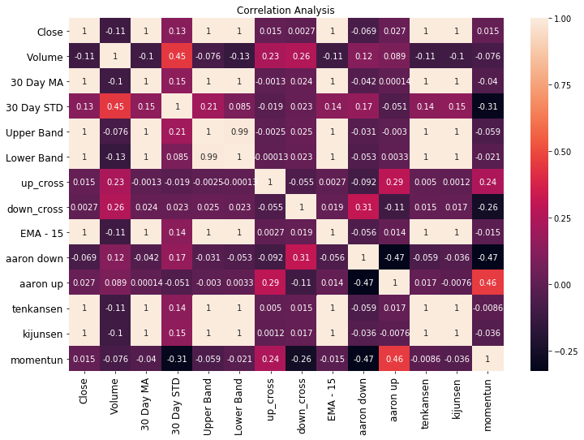

```python
c = Corr(df)
c.pearson()
```

Como esperado pode-se observar uma alta correlação entre as médias móveis e ichimoku com Close, essa correlação pode servir de base pra criar uma feature selection.

## 4 Prepare the data to better spose the underlying patterns to Machine Learning algorithms

Os algoritmos de machine learning precisam que os dados estejam preparados para sua execução, veremos melhor a diante. O primeiro passo é definir uma variável target onde o algoritmo usará essa variável nos testes e treinos, também será a variável que as predições são realizadas.

### Criando variável target

Como os indicadores estão calculados o próximo passo é definir uma variável target para o algoritmo classificar.

O método utilizado é look ahead, descrito abaixo:

[output not shown]

```python
class Target(object):
    def __init__(self, candles):
        self.candles = candles
        self.close = self.candles['Close'].tolist()


    def test_target(self, shift):
        df['buy'] = df.Close[(df.Close.shift(1) > df.Close) & (df.Close.shift(-1) > df.Close)]
        df['sell'] = df.Close[(df.Close.shift(1) < df.Close) & (df.Close.shift(-1) < df.Close)]
        hold = []
        for idx, value in enumerate(df['Close']):
            if (np.isnan(df['buy'][idx]) and np.isnan(df['sell'][idx])): #and (df['max'][idx] == np.nan):
                hold.append(value)
            else:
                hold.append(np.nan)
        df['hold'] = hold

    def plot_targets(self):
        TOOLS = "pan,wheel_zoom,box_zoom,reset,save"
        p = figure(x_axis_type="datetime", tools=TOOLS, plot_width=1000, title = "Target Chart")
        p.xaxis.major_label_orientation = pi/4
        p.grid.grid_line_alpha=0.3

        p.line(self.candles.date, self.candles.Close, line_color="black")

        p.circle(self.candles.date, self.candles['sell'], size=5, color="red", alpha=1, legend='buy')
        p.circle(self.candles.date, self.candles['buy'], size=5, color="green", alpha=1, legend='sell')
        p.circle(self.candles.date, self.candles['hold'], size=2, color="blue", alpha=1, legend='hold')
        output_notebook()
        return p
```

### Visualização do target

O resultado gráfico do look ahead pode ser observado abaixo:

```python
tgt = Target(df)
tgt.test_target(5)
plot = tgt.plot_targets()
show(plot)
```

[interactive chart not shown]

```python
tgt.candles
```

[output not shown]

5192 rows × 22 columns

### Agora que percebemos que essa estratégia de definição do target é razoável adicionamos ao dataframe

Adiciona-se o target ao dataframe:

```python
def createTarget(candles):
    df = candles.fillna(0)
    target = []
    for idx in range(len(df['buy'])):
        if (df['buy'][idx] > 0):
            target.append(0)
        if (df['sell'][idx] > 0):
            target.append(1)
        if (df['hold'][idx] > 0):
            target.append(2)
    return target
```

```python
candles = tgt.candles
candles['target'] = createTarget(candles)
```

## Teste de acerto do target

Esse método é muito simples e pode ter sua eficiência facilmente medida percorrendo cada target, verificando a mudança de sinal e classificando o trade como vencedor ou perdedor.

Se o preço na mudança de sinal de um trade de 0 para 1 o preço anterior for maior que o posterior o trade é vencedor, senão é perdedor (respeitando a lei da vida: compre na baixa e venda na alta).

```python
class TestTarget():

    def __init__(self, candles):
        self.last_index = 0
        self.winner = 0
        self.loser = 0
        self.last_buy = 0
        self.candles = candles
        self.win_percent = 0
        self.lose_percent = 0
        self.total_trades = 0

    def test(self):
        for candle in range (len(self.candles)):
            if(self.candles['target'][candle] == self.candles['target'][self.last_index]): #compara os atuais
                pass

            elif (self.candles['target'][candle] == 2 and self.candles['target'][self.last_index] == 1):
                pass

            elif (self.candles['target'][candle] == 2 and self.candles['target'][self.last_index] == 0):
                pass

            elif (self.candles['target'][candle] == 0 and self.candles['target'][self.last_index] == 1):
                self.last_index = candle
                self.last_buy = self.candles['Close'][candle]
            else:
                if (self.last_buy == 0):
                    pass
                elif (self.last_buy < self.candles['Close'][candle]):
                    self.winner += 1
                else:
                    self.loser += 1
                self.last_index = candle

    def eval_metrics(self):
        self.total_trades = self.winner + self.loser
        self.win_percent = self.winner / self.total_trades
        self.loss_percent = 1 - self.win_percent
```

```python
test = TestTarget(tgt.candles)
test.test()
```

#### Métricas do teste

Obs: Essas métricas de forma alguma avaliam com perfeição a estratégia, existem outros c[alculos mais complexos usados que não seram abordados aqui como drawndown, fator de risco e etc...

```python
test.eval_metrics()
print('Numero de acertos: {} \nNumero de erros: {} \nPorcentagem de acerto: {} \nPorcentagem de erro: {}'
      .format(test.winner, test.loser, test.win_percent, test.loss_percent) )
```

```
Numero de acertos: 1453
Numero de erros: 0
Porcentagem de acerto: 1.0
Porcentagem de erro: 0.0
```

### Limpeza dos dados

Para treinar os algoritmos são necessárias ações em relação a limpeza dos dados, para isso remove-se as colunas buy e sell que não são mais necessárias e remove-se também todas as colunas NaN (data missing). Também realiza-se um backup do dataset como csv.

```python
class cleanData(object):
    def __init__(self, candles):
        self.candles = candles

    def clean(self):
        try:
            self.candles = self.candles.drop(['sell', 'buy'], axis=1)
        except:
            pass

        self.candles = self.candles.dropna()
        for column in self.candles:
            self.candles = self.candles[~self.candles[column].isin(['NaN'])]

        self.candles.to_csv('csv_ok', sep=',', encoding='utf-8')
        return self.candles
```

Abaixo o dataframe limpo:

```python
dt = cleanData(targ)
candles_no_NaN = dt.clean()
candles_no_NaN.head()
```

[output not shown]

# Definindo target, features e dividindo treino e teste

Para a execução e validação dos algoritmos divide-se o dataset em treino e teste, onde 80% no caso é usado para treino e os outros 20% para testes.

Nesse passo também deve-se realizar a feature selection, que serão os inputs do seu algoritmo (nesse caso não se aplicou nenhuma técnica, somente a remoção da feature Data).

Também modela a entrada e saída dos algorítmos mapeando a equação.

```python
from sklearn.model_selection import train_test_split

train, test = train_test_split(candles_no_NaN, test_size=round(len(candles_no_NaN)*0.2))

train['target'] = pd.to_numeric(train['target'], downcast='float')
test['target'] = pd.to_numeric(test['target'], downcast='float')

features = ['Open', 'High', 'Low', 'Close', 'Volume', '30 Day MA',
                   '30 Day STD', 'Upper Band', 'Lower Band', 'up_cross', 'down_cross',
                   'EMA - 15', 'aaron down', 'aaron up', 'tenkansen', 'kijunsen',
                   'momentun']

x_train = train[features]
y_train = train['target']
x_test = test[features]
y_test = test['target']
```

# 5 Explore many diferent models and short-list the best ones

A parte mais custosa do processo já se encerrou, agora entra a parte mais divertida onde testamos os algoritmos de classificação para verificar quem dá o melhor resultado no nosso problema.

#### Primeiro cria-se um modelo simples de decision tree, vejamos:

1 Criar a decision tree

```python
from sklearn.tree import DecisionTreeClassifier, export_graphviz

tree = DecisionTreeClassifier(min_samples_split=100)
dct = tree.fit(x_train, y_train)
```

2 É bem legal visualizar a árvore resultante:

```python
import pydotplus
import io
from scipy import misc

def showTree(tree, features, path):
    file=io.StringIO()
    export_graphviz(tree, out_file=file, feature_names=features)
    pydotplus.graph_from_dot_data(file.getvalue()).write_png(path)
    img = misc.imread(path)
    plt.rcParams["figure.figsize"] = (20, 20)
    plt.imshow(img)
```

```
CPU times: user 150 ms, sys: 4.1 ms, total: 154 ms
Wall time: 655 ms
```

[figure not shown]

```python
%%time
showTree(dct, features, 'minhaprimeiradct.png')
```

Para ver o desempenho do algoritmo primeiro testa-se previsões com o dataset de test e em seguida calcula-se o acerto.

```python
from sklearn.metrics import accuracy_score

y_pred = tree.predict(x_test)
score = accuracy_score(y_test, y_pred)*100
print('Score = {}'.format(score))
```

```
Score = 63.829787234042556
```

#### Problemas

- 1 Os dados não estavam normalizados
- 2 Árvores de decisão tem um grande número de impurezas e não são a melhor opção para a aplicação
- 3 Rodamos o algoritmo com todos os hyperparametros e features default
- 4 O método de teste usado não é confiável

#### Soluções para os problemas

- 1 Normalizar os dados na mesma escala, o scklearn tem algumas técnicas de normalização como StandardScaler e MinMaxScaler
- 2 Testar algoritmos mais elaborados, existem muitos a disposição como Random Forest e Gradient Boosting
- 3 Otimizar hiperparametros com técnicas como por exemplo GradientSearch e Bagging
- 4 Testar com K-fold

# Pipelines

Para corrigir alguns erros e testar mais algoritmos com menos exforço usamos pipelines onde se encapsula os algoritmos para que possam ser treinados com maior facilidade.

### Criando pipelines para teste dos modelos

#### Crio 4 pipelines e verifico a acurácia de todos com cross validation com 5 dobras utilizando diferentes combinações de scallers

- pipeline 1 random forest com standart scaller
- pipeline 2 random forest com minmaxacaller
- pipeline 3 suport vector machines com minmaxscaller
- pipeline 4 gradient boosting com minmaxscaller

```python
# Scallers pra padronizar os dados no momento testarei 2 nos pipelines
from sklearn.preprocessing import StandardScaler
from sklearn.preprocessing import MinMaxScaler

# Validações e otimizações
from sklearn.model_selection import cross_val_score
from sklearn.metrics import confusion_matrix

#pipelines e gridsearch
from sklearn import preprocessing
from sklearn.pipeline import make_pipeline
from sklearn.model_selection import GridSearchCV
from sklearn.pipeline import Pipeline

#algoritmos
from sklearn import svm
from sklearn.ensemble import RandomForestClassifier
from sklearn.ensemble import GradientBoostingClassifier
from sklearn.ensemble import VotingClassifier
from sklearn.ensemble import BaggingClassifier
from sklearn.ensemble import AdaBoostClassifier

from sklearn.linear_model import LogisticRegression
from sklearn.neighbors import KNeighborsClassifier
```

```python
pip_1 = Pipeline([
    ('scaler',StandardScaler()),
    ('clf', RandomForestClassifier())
])

pip_1.fit(x_train, y_train)
np.mean(cross_val_score(pip_1, x_train, y_train, cv=5))
```

```
0.7704713134186818
```

```python
pip_2 = Pipeline([
    ('min_max_scaler', MinMaxScaler()),
    ('clf', BaggingClassifier(RandomForestClassifier()))
])

pip_2.fit(x_train, y_train)
np.mean(cross_val_score(pip_2, x_train, y_train, cv=5))
```

```
0.8078795637743006
```

```python
pip_3 = Pipeline([
    ('min_max_scaler', MinMaxScaler()),
    ('clf', svm.SVC())
])

pip_3.fit(x_train, y_train)
np.mean(cross_val_score(pip_3, x_train, y_train, cv=5))
```

```
0.538597439544808
```

```python
pip_4 = Pipeline([
    ('min_max_scaler', MinMaxScaler()),
    ('clf', GradientBoostingClassifier())
])

pip_4.fit(x_train, y_train)
np.mean(cross_val_score(pip_4, x_train, y_train, cv=5))
```

```
0.7943669985775249
```

### Como esperado

Os modelos com melhor resultado foram BaggingClassifier(RandomForestClassifier()) onde combinamos RandomForest com a técnica de Bagging e o algoritmo GradientBoostingClassifier(), que já possui um ótimo histórico e vence muitas competições no Kaggle.